# CFRM 521, Spring 2020

# Course Project: A Model Comparison of Forecasting Hourly Real-Time Wholesale Power Prices at SPP North Hub

Problem Statement:

Electricity price forecasting is a heavily-studied subject in quantitative finance within the energy industry. Rafal Weron published a paper in the International Journal of Forecasting 30 (2014) 1030-1081 "Electricity price forecasting: A review of the state-of-the-art with a look into the future" describing the strengths and weaknesses of commonly used modelling techniques, ranging from jump-diffusion models, Markov regime switching models, statistical models (regression, AR-type, ARX-type, GARCH-type), and computational intelligence models (including support vector machines, decision trees, feedforward artificial neural networks and recurrent neural networks).

Weron's concludes his assessment of different NN computational models by stating...

"The pool of available CI (computational intelligence) tools is so diverse and rich that it is hard to find an optimal solution. Worse still, it is hard to compare the different CI methods thoroughly. Even if the forecasting accuracy is reported for the same market and the same out-of-sample (forecasting) test period, the errors of the individual methods are not truly comparable unless identical in-sample (calibration) periods are used as well, and therefore they cannot be used to formulate general statements about a method's efficiency unless such is the case."

After describing the broad range of electricity price forecasting techniques, Weron summarizes his conclusions as ...

"All of this calls for a comprehensive, thorough study involving (i) the same datasets, (ii) the same robust evaluation procedures, and (iii) statistical testing of the significance of one model's outperformance of another". (Weron p.1073)

The purpose of this project is to compare the performance of two different computational intelligence (neural network) models, as well as a timeseries benchmark model, on the same in-sample and out-of-sample dataset using robust empirical procedures for evaluating the significance of modelling performance.

- Benchmark models (3): Regression, AR model, Multiple Seasonality TBATS
- Extra Trees Regressor
- Random Forest Regressor
- Artificial Neural Network

Compare the Root Mean Squared Error on out-of-sample data in each model and determine if there is empirical evidence to support the significant outperformance of one model over the others.

To properly answer such a question I will try each Neural Network algorithm with a range of values of its parameters, determine the best fitting parameters of each model, and assess the statistical significance of the forecasting errors between the models.

Statistical Significance in Forecast Errors between Models:

In addition to comparing the RMSE on the test set between the models, I perform a student's t-test on the test set prediction errors between the best models of each type, and check p-values < .05 for statistically significant differences in the forecast errors.

Dataset Features & Response Variable:

This project is a comparison of regression models which predict the hourly wholesale electricity price at Southwest Power Pools Real Time "SPP North Hub" LMP. This represents the "Y" response variable, which may also be referred as "Power Price" throughout this report.

The complete raw dataset contains 24,900 observations of hours spanning July 21st, 2017 (Hour Ending 11) through May 26th 2020 Hour Ending 24. Each observation represents one hourly interval.

Background on Power Price Formulation:

The real-time electricity market in SPP solves for the lowest marginal price required to serve every Mega-watt ("MW" a unit of energy flow expressed over a period of time, e.g. each hour yields a MWh unit of total system demand for electricity) of Demand (aka "Load") subject to constraints on the transmission lines of the system.

Each generator offers to produce energy at a bid price in each hour, and SPP (the overall grid operator) aggregates the generation stack from cheapest unit to most expensive units. The grid operator determines the load requirement from all users of the system each hour, and directs all lowest-cost generators to run up until the system has generated all the required demand load. The generator serving the last MW of required load will set the market clearing price for all generators, effectively the system-wide energy price.

```python
## Import packages
import pandas as pd
import numpy as np
from pandas.plotting import scatter_matrix
# from pandas.plotting import register_matplotlib_converters
from statsmodels.tsa.seasonal import seasonal_decompose
from pmdarima import auto_arima
from pmdarima import arima
from tbats import TBATS, BATS
import sklearn.metrics
from sklearn.metrics import mean_squared_error, make_scorer
from sklearn.ensemble import ExtraTreesRegressor
from sklearn.ensemble import RandomForestRegressor
import time
from sklearn.pipeline import Pipeline
from sklearn.compose import ColumnTransformer
from sklearn.preprocessing import OrdinalEncoder, OneHotEncoder
from sklearn.preprocessing import MinMaxScaler, StandardScaler
from sklearn.metrics import accuracy_score
from sklearn.model_selection import cross_val_score
from sklearn.model_selection import RandomizedSearchCV
from sklearn.model_selection import GridSearchCV
from scipy.stats import randint
from sklearn.impute import SimpleImputer
from matplotlib import pyplot

# define the grid search parameters
from keras import backend as K
from keras.wrappers.scikit_learn import KerasRegressor
from sklearn.metrics import mean_squared_error

import warnings
warnings.filterwarnings("ignore")

# Plotting
%matplotlib inline
import matplotlib as mpl
import matplotlib.pyplot as plt

import tensorflow as tf
import tensorflow.keras as keras
print(tf.__version__)
print(keras.__version__)

def reset_session(seed=42):
    tf.random.set_seed(seed)
    np.random.seed(seed)
    tf.keras.backend.clear_session()

def ts_split(ts, feature_steps=5*24, target_steps=1):
    n_obs = len(ts) - feature_steps - target_steps + 1
    X = np.array([ts[idx:idx + feature_steps] for idx in range(n_obs)])
    y = np.array([ts[idx + feature_steps:idx + feature_steps + target_steps]
                  for idx in range(n_obs)])
    return X, y
```

```
2.0.0
2.2.4-tf
```

```python
## Read data
data = pd.read_csv("SPP_HourlyData_2017_v3.csv")
```

The features in this dataset include hourly observations for each of the following variables:

HOURLY DATA

- Time (categorical variables converted to onehotencoders)
  - Month
  - Hour Ending
  - Day of week
- Load (demand) real-time
- Generation quantities in total across SPP by fuel type in real-time
  - Wind, natural gas, coal, hydro, solar, nuclear
- Total generation unit capacity on outage by fuel type in real time
  - Wind, natural gas, coal, hydro, solar, nuclear
- Actual observed temperatures, wind speeds, cloud coverage
  - 3 locations each
- Wind speeds
  - 3 locations
- Hourly differences in each variable above

DAILY DATA - copied for every hour in each day

- Daily natural gas spot prices
  - 3 locations each
- Coal prices (prompt month futures price)
  - 3 locations
- Total installed generation capacity in SPP by fuel type, aggregated by plant heat rate (plant efficiency rating)
  - Less variability each day, but changes over the years

Additional Features

- The prior five days of hourly price changes are added to the data set for use in the AR Regression model

```python
data.info()
```

```
<class 'pandas.core.frame.DataFrame'>
RangeIndex: 24900 entries, 0 to 24899
Data columns (total 87 columns):
DATETIME                                            24900 non-null object
HOURENDING                                          24900 non-null int64
MONTH                                               24900 non-null int64
DAYOFWEEK                                           24900 non-null int64
SPPNORTH_HUB..RTLMP.                                24900 non-null float64
SPPISO..RTLOAD.                                     24900 non-null float64
SPPISO..WIND_RTI.                                   24900 non-null float64
SPPISO..HYDRO_RT.                                   24900 non-null float64
SPPISO..NUCLEARGEN_5MIN.                            24900 non-null float64
SPPISO..COALGEN_5MIN.                               24900 non-null float64
SPPISO..GASGEN_5MIN.                                24900 non-null float64
TX...Amarillo.Intl..TEMP_F.                         24766 non-null float64
OK...Oklahoma.City..TEMP_F.                         24831 non-null float64
KS...Wichita.Municipal..WIND_MPH.                   24795 non-null float64
KS...Dodge.City.NWSFO..WIND_MPH.                    24738 non-null float64
OK...Oklahoma.City..WIND_MPH.                       24827 non-null float64
MT...Billings.Logan.Intl..CLOUD_COVER_PCT.          24732 non-null float64
NE...Lincoln.Municipal..CLOUD_COVER_PCT.            24677 non-null float64
OK...Tulsa.Intl..CLOUD_COVER_PCT.                   24712 non-null float64
KS...Dodge.City.NWSFO..TEMP_F.                      24793 non-null float64
OK...Oklahoma.City..TEMP_F..1                       24831 non-null float64
NE...Lincoln.Municipal..TEMP_F.                     24795 non-null float64
SPPISO..TOT_RT_CONG_BY_ISO.                         24900 non-null float64
SPPISO..ISO_CAPACITY_OFFLINE.                       24900 non-null float64
SPPISO..COAL_CAPACITY_OFFLINE.                      24900 non-null float64
SPPISO..NG_CAPACITY_OFFLINE.                        24900 non-null float64
SPPISO..NUCLEAR_CAPACITY_OFFLINE.                   24900 non-null float64
SPPISO..SOLAR_CAPACITY_OFFLINE.                     24900 non-null float64
SPPISO..WIND_CAPACITY_OFFLINE.                      24900 non-null float64
SPPISO..HYDRO_CAPACITY_OFFLINE.                     24900 non-null float64
SPPISO..RTLOAD._Delta                               24900 non-null float64
SPPISO..WIND_RTI._Delta                             24900 non-null float64
SPPISO..HYDRO_RT._Delta                             24900 non-null float64
SPPISO..NUCLEARGEN_5MIN._Delta                      24900 non-null float64
SPPISO..COALGEN_5MIN._Delta                         24900 non-null float64
SPPISO..GASGEN_5MIN._Delta                          24900 non-null float64
TX...Amarillo.Intl..TEMP_F._Delta                   24716 non-null float64
```

[output cut: 37 more lines]

```
NatGas_6_7                                          24900 non-null float64
NatGas_7_8                                          24900 non-null float64
NatGas_8_9                                          24900 non-null float64
NatGas_9_10                                         24900 non-null float64
NatGas_10_11                                        24900 non-null float64
NatGas_11_12                                        24900 non-null float64
NatGas_12_13                                        24900 non-null float64
NatGas_13_14                                        24900 non-null float64
NatGas_14_15                                        24900 non-null float64
NatGas_15_16                                        24900 non-null float64
NatGas_16_17                                        24900 non-null float64
NatGas_17_18                                        24900 non-null float64
NatGas_18_19                                        24900 non-null int64
dtypes: float64(81), int64(5), object(1)
memory usage: 16.5+ MB
```

```python
data.head()
```

|  | DATETIME | HOURENDING | MONTH | DAYOFWEEK | SPPNORTH_HUB..RTLMP. | SPPISO..RTLOAD. | SPPISO..WIND_RTI. | SPPISO..HYDRO_RT. | SPPISO..NUCLEARGEN_5MIN. | SPPISO..COALGEN_5MIN. | ... | NatGas_9_10 | NatGas_10_11 | NatGas_11_12 | NatGas_12_13 | NatGas_13_14 | NatGas_14_15 | NatGas_15_16 | NatGas_16_17 | NatGas_17_18 | NatGas_18_19 |
| --- | --- | --- | --- | --- | --- | --- | --- | --- | --- | --- | --- | --- | --- | --- | --- | --- | --- | --- | --- | --- | --- |
| 0 | 7/21/2017 11:00 | 11 | 7 | 5 | 63.06 | 42938.83 | 6438.72 | 2027.18 | 1958.38 | 19121.09 | ... | 2178.9 | 8183.9 | 6675.6 | 2031.3 | 1194.6 | 317.2 | 458.9 | 171.6 | 38.7 | 0 |
| 1 | 7/21/2017 12:00 | 12 | 7 | 5 | 34.77 | 45202.50 | 5734.93 | 2076.72 | 1957.71 | 19495.16 | ... | 2178.9 | 8183.9 | 6675.6 | 2031.3 | 1194.6 | 317.2 | 458.9 | 171.6 | 38.7 | 0 |
| 2 | 7/21/2017 13:00 | 13 | 7 | 5 | 35.46 | 47001.33 | 5213.53 | 2316.05 | 1957.51 | 19679.02 | ... | 2178.9 | 8183.9 | 6675.6 | 2031.3 | 1194.6 | 317.2 | 458.9 | 171.6 | 38.7 | 0 |
| 3 | 7/21/2017 14:00 | 14 | 7 | 5 | 39.15 | 48641.17 | 5270.13 | 2208.58 | 1956.10 | 19783.09 | ... | 2178.9 | 8183.9 | 6675.6 | 2031.3 | 1194.6 | 317.2 | 458.9 | 171.6 | 38.7 | 0 |
| 4 | 7/21/2017 15:00 | 15 | 7 | 5 | 41.65 | 49586.75 | 5434.93 | 2196.91 | 1956.88 | 19770.78 | ... | 2178.9 | 8183.9 | 6675.6 | 2031.3 | 1194.6 | 317.2 | 458.9 | 171.6 | 38.7 | 0 |

5 rows × 87 columns

There are some missing data observations in the wind speed variables and gas price variables, to address this the following code fills missing/NaN observations with the value from the previous observation.

```python
data[data.isnull().any(axis=1)].shape
```

```
(908, 87)
```

```python
data.fillna(method='ffill', inplace=True)
```

The following code describes the summary statistics of the complete data set.

```python
data.describe().transpose()
```

|  | count | mean | std | min | 25% | 50% | 75% | max |
| --- | --- | --- | --- | --- | --- | --- | --- | --- |
| HOURENDING | 24900.0 | 12.501526 | 6.921182e+00 | 1.000 | 7.0000 | 13.000 | 18.0000 | 24.000 |
| MONTH | 24900.0 | 6.531446 | 3.535948e+00 | 1.000 | 3.0000 | 7.000 | 10.0000 | 12.000 |
| DAYOFWEEK | 24900.0 | 4.000040 | 2.001516e+00 | 1.000 | 2.0000 | 4.000 | 6.0000 | 7.000 |
| SPPNORTH_HUB..RTLMP. | 24900.0 | 20.740167 | 2.684328e+01 | -48.980 | 12.8900 | 17.280 | 22.5000 | 1130.720 |
| SPPISO..RTLOAD. | 24900.0 | 30311.410555 | 5.211736e+03 | 20362.420 | 26801.3150 | 29248.080 | 32897.4150 | 50655.670 |
| SPPISO..WIND_RTI. | 24900.0 | 7929.630688 | 4.010551e+03 | 164.170 | 4541.1850 | 7695.890 | 11273.8525 | 18084.080 |
| SPPISO..HYDRO_RT. | 24900.0 | 1541.911918 | 5.367994e+02 | 331.550 | 1172.6625 | 1555.420 | 1956.9500 | 2756.180 |
| SPPISO..NUCLEARGEN_5MIN. | 24900.0 | 1843.273876 | 3.859036e+02 | 519.660 | 1968.1225 | 2015.980 | 2032.9300 | 2043.540 |
| SPPISO..COALGEN_5MIN. | 24900.0 | 11738.982573 | 4.115198e+03 | 2230.560 | 8509.5225 | 11576.445 | 14784.6500 | 22532.270 |
| SPPISO..GASGEN_5MIN. | 24900.0 | 7421.754943 | 3.425205e+03 | 1322.450 | 4831.0850 | 6812.765 | 9323.8850 | 23206.600 |
| TX...Amarillo.Intl..TEMP_F. | 24900.0 | 57.136976 | 1.952023e+01 | 3.000 | 42.1000 | 57.900 | 72.0000 | 107.100 |
| OK...Oklahoma.City..TEMP_F. | 24900.0 | 58.797205 | 1.886862e+01 | 3.900 | 44.1000 | 60.100 | 73.9000 | 109.000 |
| KS...Wichita.Municipal..WIND_MPH. | 24900.0 | 11.224534 | 6.312742e+00 | 0.000 | 6.9000 | 10.400 | 15.0000 | 40.300 |
| KS...Dodge.City.NWSFO..WIND_MPH. | 24900.0 | 12.542578 | 6.506915e+00 | 0.000 | 8.1000 | 11.500 | 16.1000 | 44.900 |
| OK...Oklahoma.City..WIND_MPH. | 24900.0 | 11.096711 | 6.126529e+00 | 0.000 | 6.9000 | 10.400 | 15.0000 | 41.400 |
| MT...Billings.Logan.Intl..CLOUD_COVER_PCT. | 24900.0 | 57.327459 | 3.475969e+01 | 0.000 | 25.0000 | 75.000 | 75.0000 | 100.000 |
| NE...Lincoln.Municipal..CLOUD_COVER_PCT. | 24900.0 | 36.897255 | 4.497634e+01 | 0.000 | 0.0000 | 0.000 | 100.0000 | 100.000 |
| OK...Tulsa.Intl..CLOUD_COVER_PCT. | 24900.0 | 59.299300 | 3.844405e+01 | 0.000 | 25.0000 | 75.000 | 100.0000 | 100.000 |
| KS...Dodge.City.NWSFO..TEMP_F. | 24900.0 | 53.994984 | 2.113515e+01 | -8.000 | 37.0000 | 54.000 | 71.0000 | 105.100 |
| OK...Oklahoma.City..TEMP_F..1 | 24900.0 | 58.797205 | 1.886862e+01 | 3.900 | 44.1000 | 60.100 | 73.9000 | 109.000 |
| NE...Lincoln.Municipal..TEMP_F. | 24900.0 | 50.613072 | 2.228917e+01 | -18.000 | 33.1000 | 50.000 | 69.1000 | 100.000 |
| SPPISO..TOT_RT_CONG_BY_ISO. | 24900.0 | 504.737218 | 7.170127e+02 | 0.000 | 35.5275 | 231.520 | 691.8550 | 12085.070 |
| SPPISO..ISO_CAPACITY_OFFLINE. | 24900.0 | 15839.050127 | 5.511671e+03 | 4775.090 | 11445.2250 | 15154.835 | 19513.9100 | 29917.670 |
| SPPISO..COAL_CAPACITY_OFFLINE. | 24900.0 | 5498.327273 | 2.710080e+03 | 640.000 | 3248.0000 | 5026.000 | 7300.4000 | 14572.400 |
| SPPISO..NG_CAPACITY_OFFLINE. | 24900.0 | 8455.750980 | 3.105842e+03 | 1826.100 | 6565.2000 | 8370.300 | 10326.4000 | 17955.800 |
| SPPISO..NUCLEAR_CAPACITY_OFFLINE. | 24900.0 | 165.406988 | 3.967652e+02 | 0.000 | 0.0000 | 0.000 | 0.0000 | 1241.000 |
| SPPISO..SOLAR_CAPACITY_OFFLINE. | 24900.0 | 0.348394 | 3.239212e+00 | 0.000 | 0.0000 | 0.000 | 0.0000 | 70.000 |
| SPPISO..WIND_CAPACITY_OFFLINE. | 24900.0 | 964.475439 | 5.652763e+02 | 109.100 | 527.1500 | 866.050 | 1242.7900 | 3182.260 |
| SPPISO..HYDRO_CAPACITY_OFFLINE. | 24900.0 | 558.982239 | 1.967958e+02 | 180.000 | 407.0000 | 527.000 | 694.0000 | 1674.000 |
| SPPISO..RTLOAD._Delta | 24900.0 | -0.651407 | 1.026145e+03 | -6705.250 | -637.4400 | -81.000 | 651.9150 | 5834.520 |
| ... | ... | ... | ... | ... | ... | ... | ... | ... |
| ONEOK_GasPrice | 24900.0 | 1.923185 | 6.360169e-01 | 0.200 | 1.5100 | 1.780 | 2.2700 | 5.800 |
| NGPL Midcont_GasPrice | 24900.0 | 2.685478 | 5.984229e-01 | 1.450 | 2.3100 | 2.720 | 2.9300 | 6.880 |
| Colo High Btu Rail | 24900.0 | 1.431029 | 1.214186e-01 | 1.230 | 1.3200 | 1.410 | 1.5400 | 1.620 |
| CSX Big Sandy Mid Sulfur Rail | 24900.0 | 2.300205 | 4.517628e-01 | 1.440 | 1.8400 | 2.340 | 2.5500 | 3.080 |
| Illinois Basin Mid Sulfur Barge | 24900.0 | 1.692251 | 2.174567e-01 | 1.360 | 1.5000 | 1.650 | 1.8600 | 2.120 |
| PRB Low Btu Rail | 24900.0 | 0.559522 | 1.627250e-02 | 0.520 | 0.5500 | 0.570 | 0.5700 | 0.580 |
| Wind_CAP | 24900.0 | 16348.799666 | 1.316698e+03 | 14208.420 | 15389.7100 | 16047.210 | 17903.0100 | 18199.010 |
| Nuclear_CAP | 24900.0 | 1291.310000 | 0.000000e+00 | 1291.310 | 1291.3100 | 1291.310 | 1291.3100 | 1291.310 |
| Hydro_CA{ | 24900.0 | 2426.798434 | 1.051375e+01 | 2387.690 | 2427.6900 | 2427.690 | 2432.6900 | 2432.690 |
| Solar_CAP | 24900.0 | 314.047067 | 2.617062e+01 | 268.730 | 302.4200 | 310.920 | 318.5900 | 370.590 |
| FuelOil_CAP | 24900.0 | 2694.200020 | 2.570009e+00 | 2688.600 | 2693.7000 | 2693.700 | 2697.7000 | 2697.700 |
| Biomass_CAP | 24900.0 | 386.777305 | 1.655582e+01 | 360.000 | 381.9000 | 381.900 | 410.0000 | 410.000 |
| Coal_HR_8_9 | 24900.0 | 1523.000000 | 0.000000e+00 | 1523.000 | 1523.0000 | 1523.000 | 1523.0000 | 1523.000 |
| Coal_HR_9_10 | 24900.0 | 4924.900000 | 0.000000e+00 | 4924.900 | 4924.9000 | 4924.900 | 4924.9000 | 4924.900 |
| Coal_HR_10_11 | 24900.0 | 10926.709960 | 8.095096e+02 | 10013.900 | 10013.9000 | 11681.900 | 11681.9000 | 11681.900 |
| Coal_HR_11_12 | 24900.0 | 2085.718153 | 2.380402e+02 | 1846.500 | 1846.5000 | 2222.500 | 2304.5000 | 2392.500 |
| Coal_HR_12_13 | 24900.0 | 0.000000 | 0.000000e+00 | 0.000 | 0.0000 | 0.000 | 0.0000 | 0.000 |
| NatGas_6_7 | 24900.0 | 1862.900000 | 4.547565e-13 | 1862.900 | 1862.9000 | 1862.900 | 1862.9000 | 1862.900 |
| NatGas_7_8 | 24900.0 | 9009.100000 | 1.819026e-12 | 9009.100 | 9009.1000 | 9009.100 | 9009.1000 | 9009.100 |
| NatGas_8_9 | 24900.0 | 2767.607337 | 3.746689e+00 | 2763.698 | 2763.6980 | 2771.198 | 2771.1980 | 2771.198 |
| NatGas_9_10 | 24900.0 | 2592.991406 | 1.437985e+02 | 2178.900 | 2640.9000 | 2640.900 | 2677.9000 | 2677.900 |
| NatGas_10_11 | 24900.0 | 8029.196884 | 3.670485e+02 | 7196.700 | 7796.7000 | 8182.700 | 8340.7000 | 8340.700 |
| NatGas_11_12 | 24900.0 | 6673.943550 | 2.131839e+00 | 6671.200 | 6671.2000 | 6675.600 | 6675.6000 | 6675.600 |
| NatGas_12_13 | 24900.0 | 2024.557510 | 2.911888e+00 | 2023.300 | 2023.3000 | 2023.300 | 2023.3000 | 2031.300 |
| NatGas_13_14 | 24900.0 | 1194.600000 | 0.000000e+00 | 1194.600 | 1194.6000 | 1194.600 | 1194.6000 | 1194.600 |
| NatGas_14_15 | 24900.0 | 317.200000 | 5.684456e-14 | 317.200 | 317.2000 | 317.200 | 317.2000 | 317.200 |
| NatGas_15_16 | 24900.0 | 445.162177 | 5.932971e+00 | 442.600 | 442.6000 | 442.600 | 442.6000 | 458.900 |
| NatGas_16_17 | 24900.0 | 171.600000 | 2.842228e-14 | 171.600 | 171.6000 | 171.600 | 171.6000 | 171.600 |
| NatGas_17_18 | 24900.0 | 38.700000 | 0.000000e+00 | 38.700 | 38.7000 | 38.700 | 38.7000 | 38.700 |
| NatGas_18_19 | 24900.0 | 0.000000 | 0.000000e+00 | 0.000 | 0.0000 | 0.000 | 0.0000 | 0.000 |

86 rows × 8 columns

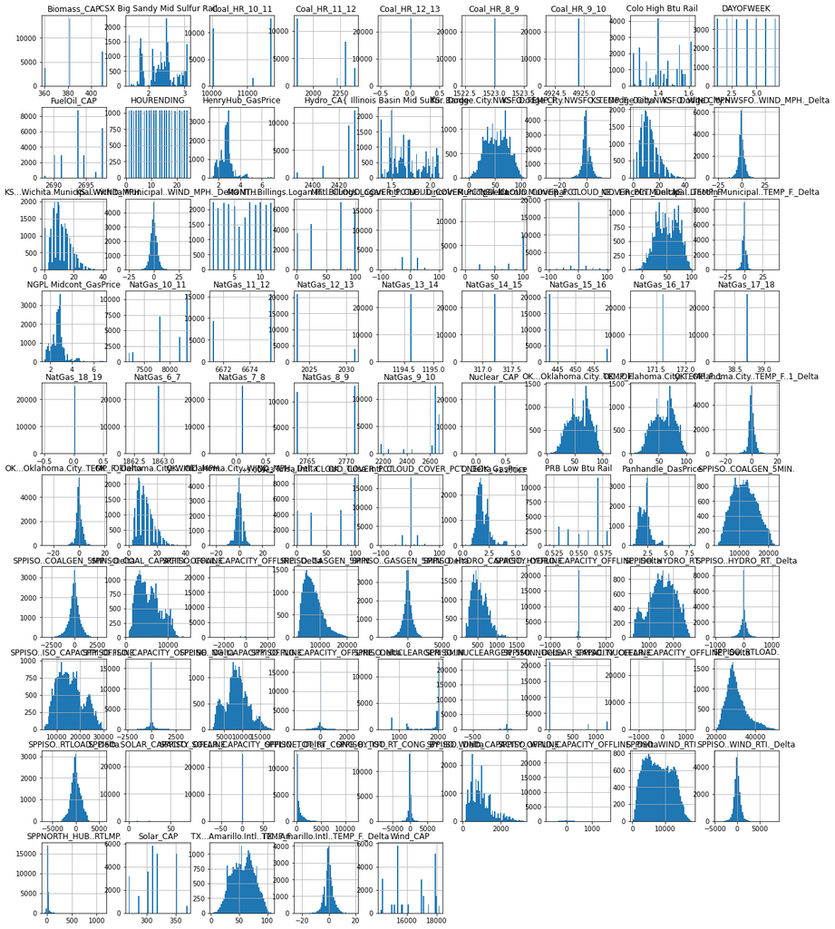

```python
data.hist(bins=50, figsize=(20,25))
plt.show()
```

[output not shown]

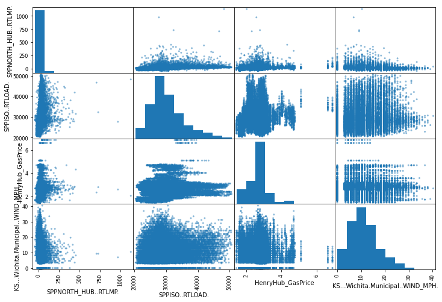

```python
# from pandas.tools.plotting import scatter_matrix # For older versions of Pandas
attributes = ["SPPNORTH_HUB..RTLMP.", "SPPISO..RTLOAD.", "HenryHub_GasPrice",
              "KS...Wichita.Municipal..WIND_MPH."]
scatter_matrix(data[attributes], figsize=(12, 8))
```

```python
data.shape
```

```
(24900, 87)
```

### Training, Validation and Test Sets

```python
## Separate features from Y (Price) response variable
y_all = data["SPPNORTH_HUB..RTLMP."]
y_raw = data["SPPNORTH_HUB..RTLMP."]  ## stored as copy for later use
X_all = data.drop(['DATETIME','SPPNORTH_HUB..RTLMP.'], axis=1)
X_all.shape, y_all.shape
```

```
((24900, 85), (24900,))
```

```python
periods_back = 24*5  # 5 days of hourly price changes are stored as new features
ts = y_all.values.flatten()
y_features_all_lm, y_all_lm = ts_split(ts, feature_steps = periods_back)
```

```python
## Add features for the 120 prior hourly price values from the Price (response) variable
y_features_all_lm = pd.DataFrame(y_features_all_lm)
strs = ["y"+str(x) for x in range(periods_back)]
y_features_all_lm.columns = strs

v1 = X_all[periods_back:]
v1.columns = X_all.columns

v2 = y_features_all_lm
v2.columns = strs

v3 = y_all[periods_back:]

v1.reset_index(drop=True, inplace=True)
v2.reset_index(drop=True, inplace=True)
v3.reset_index(drop=True, inplace=True)

# Merge X_all and hourly changes in Price
X_all_AR = pd.concat([v1, v2], axis=1, join='inner', ignore_index=True)
X_all_AR.columns = list(X_all.columns.T) + strs
y_all = v3

# Align index from original data after removing starting periods
index_all = data['DATETIME'][periods_back:]
```

```python
X_all_AR.shape, y_all.shape, y_features_all_lm.shape, index_all.shape
```

```
((24780, 205), (24780,), (24780, 120), (24780,))
```

```python
## Transform Categorical variables to OneHotEncoder
cat_attribs = ['MONTH','HOURENDING', 'DAYOFWEEK']
X_all_num = X_all_AR.drop(cat_attribs, axis=1)
X_all_cat = X_all_AR[cat_attribs]
num_attribs = list(X_all_num)

num_pipeline = Pipeline([
        ('std_scaler', StandardScaler()),
    ])

full_pipeline = ColumnTransformer([
        ("num", num_pipeline, num_attribs),
        ("cat", OneHotEncoder(), cat_attribs),
    ])
```

```python
## Separate training set on first 70% of data, validation on 20%, test on last 10%
n = X_all_AR.shape[0]
train_len = n*.75
val_len = n*.15
test_len = n*.1

# hourly Data
val_start = int(round(train_len))
val_end = val_start + int(round(val_len))

index_train = index_all[:(val_start-1)].values
index_val  = index_all[val_start:val_end].values
index_test = index_all[(val_end+1):].values

## Subset data sets, 70% in training, 10% in validation, 20% in testing
X_train_raw = X_all_AR[:(val_start-1)]
X_val_raw  = X_all_AR[val_start:val_end]
X_test_raw = X_all_AR[(val_end+1):]

## Transform features with fit_transform on training set and transform on val/test feature set
X_train = pd.DataFrame(data=full_pipeline.fit_transform(X_train_raw))
X_val = pd.DataFrame(data=full_pipeline.transform(X_val_raw))
X_test = pd.DataFrame(data=full_pipeline.transform(X_test_raw))

y_train = pd.DataFrame(data=y_all[:(val_start-1)])
y_val  = pd.DataFrame(data=y_all[val_start:val_end])
y_test = pd.DataFrame(data=y_all[(val_end+1):])

X_train.index = index_train
X_val.index = index_val
X_test.index = index_test

y_train.index = index_train
y_val.index = index_val
y_test.index = index_test
```

```python
X_train.shape, X_val.shape, X_test.shape
```

```
((18584, 245), (3717, 245), (2477, 245))
```

```python
y_train.shape, y_val.shape, y_test.shape
```

```
((18584, 1), (3717, 1), (2477, 1))
```

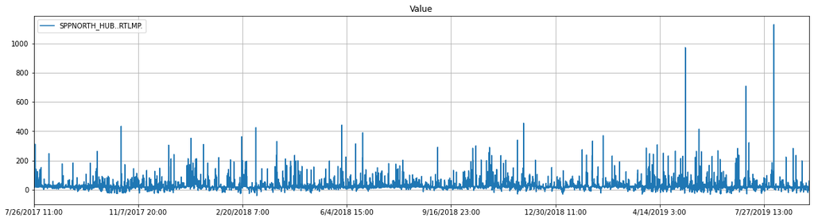

```python
# Draw Plot
def plot_df(df, df2=[], title="", xlabel='Date', ylabel='Value'):
    df.plot(figsize=(20,5))
    # df.plot(figsize=(20,5), color='tab:blue')
    plt.title(ylabel)
    plt.grid(True)
    plt.show()

plot_df(y_train)
```

## Benchmark Model #1

First we evaluate a few benchmark models, starting with a linear regression model based on categorical variables HOURENDING, MONTH and DAYOFWEEK only.

```python
## Re-create one hot encoder variables for HOURENDING, MONTH and DAYOFWEEK
cat_encoder = OneHotEncoder()
train_cat = cat_encoder.fit_transform(X_train_raw[['HOURENDING', 'MONTH', 'DAYOFWEEK']])
val_cat = cat_encoder.transform(X_val_raw[['HOURENDING', 'MONTH', 'DAYOFWEEK']])
test_cat = cat_encoder.transform(X_test_raw[['HOURENDING', 'MONTH', 'DAYOFWEEK']])

X_train_cat_1hot = pd.DataFrame(train_cat.todense())
X_val_cat_1hot = pd.DataFrame(val_cat.todense())
X_test_cat_1hot = pd.DataFrame(test_cat.todense())

cat_col = X_train_cat_1hot.shape[1]
```

```python
## Benchmark regression model
## Regression model using 1 layer ANN
reset_session()

model_CatReg = keras.models.Sequential([
    keras.layers.Flatten(input_shape=[cat_col]),
    keras.layers.Dense(1)
])

model_CatReg.compile(loss="mse", optimizer="nadam")

checkpoint_cb = keras.callbacks.ModelCheckpoint("linear_1hotcats_06-07.h5",
                                                save_best_only=True)

early_stopping_cb = keras.callbacks.EarlyStopping(patience=10,
                                                  min_delta=0.01,
                                                  restore_best_weights=True)

run = model_CatReg.fit(X_train_cat_1hot.values, y_train.values , epochs=400,
                validation_data=(X_val_cat_1hot.values, y_val.values),
                callbacks=[checkpoint_cb, early_stopping_cb])
```

```
Train on 18584 samples, validate on 3717 samples
```

```python
# Retrieve predictions over training set
CatReg_train_preds = pd.DataFrame(data=model_CatReg.predict(X_train_cat_1hot.values),
                                  index=index_train, columns=['CatReg_Pred'])

# Predict over validation set
CatReg_val_preds = pd.DataFrame(data=model_CatReg.predict(X_val_cat_1hot.values), index=index_val, columns=['CatReg_Pred'])
```

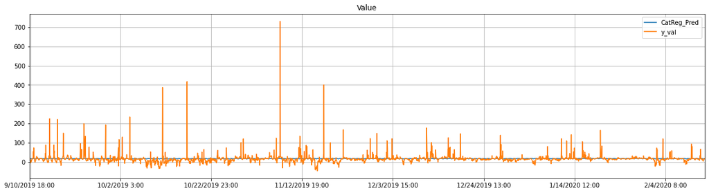

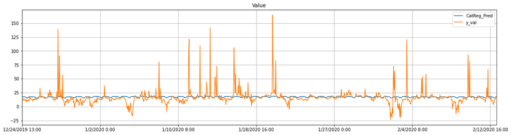

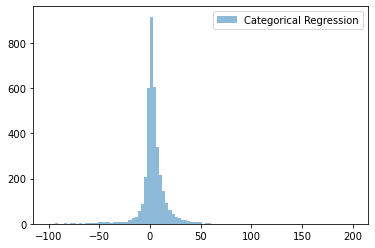

```python
# Plot validation data
CatReg_val_preds['y_val'] = y_val
plot_df(CatReg_val_preds)
plot_df(CatReg_val_preds[2500:])

## MSE on Categorical Regression model - Validation set
rmse_val_CatReg = np.sqrt(mean_squared_error(CatReg_val_preds['CatReg_Pred'].values, y_val))
CatReg_val_preds['CatReg_error'] = CatReg_val_preds['CatReg_Pred'] - CatReg_val_preds['y_val']

## Plot the histogram of validation set errors
bins = np.linspace(-100, 200, 100)
pyplot.hist(CatReg_val_preds['CatReg_error'], bins, alpha=0.5, label='Categorical Regression')
pyplot.legend(loc='upper right')
pyplot.show()
```

```python
## Performance metrics (RMSE)
print('Categorical Regression Model RMSE on Validation Set:', rmse_val_CatReg)
print('Categorical Regression Model Mean Error on Validation Set:', np.mean(CatReg_val_preds['CatReg_error']))
```

```
Categorical Regression Model RMSE on Validation Set: 24.701463312187737
Categorical Regression Model Mean Error on Validation Set: 1.0893792371567712
```

## Benchmark Timeseries Model #2

Next, we create another benchmark AR timeseries model that's based on the last 24*5 steps of hourly price changes.

```python
## Use the same 5x24 AR features from Price just for the AR model as the only features
X_train_lm = X_all_AR[strs][:(val_start-1)]
X_val_lm  = X_all_AR[strs][val_start:val_end]
X_test_lm = X_all_AR[strs][(val_end+1):]
X_train_lm.shape, X_val_lm.shape, X_test_lm.shape
```

```
((18584, 120), (3717, 120), (2477, 120))
```

```python
## Benchmark timeseries model
## AR Regression model using 1 layer ANN
reset_session()

model = keras.models.Sequential([
    keras.layers.Flatten(input_shape=[periods_back]),
    keras.layers.Dense(1)
])

model.compile(loss="mse", optimizer="nadam")

checkpoint_cb = keras.callbacks.ModelCheckpoint("linear_06-04.h5",
                                                save_best_only=True)

early_stopping_cb = keras.callbacks.EarlyStopping(patience=10,
                                                  min_delta=0.01,
                                                  restore_best_weights=True)

run = model.fit(X_train_lm.values, y_train.values , epochs=400,
                validation_data=(X_val_lm.values, y_val.values),
                callbacks=[checkpoint_cb, early_stopping_cb])
```

```
Train on 18584 samples, validate on 3717 samples
```

```python
y_raw = data["SPPNORTH_HUB..RTLMP."]
```

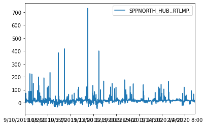

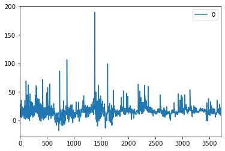

```python
# Plot Validation predictions and actual values
y = pd.DataFrame(y_val)
y.plot(legend = True)

LM_val_preds = model.predict(X_val_lm.values)
y_val_LM_preds = LM_val_preds
y_fcst = pd.DataFrame(y_val_LM_preds)
y_fcst.plot(legend = True)
```

The benchmark timeseries AR model's validation RMSE:

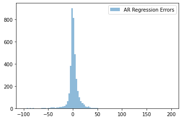

```
Linear Model with AR features RMSE on Validation Set: 23.112496055345257
Linear Model with AR features Mean Error on Validation Set: -0.43626580068813003
```

```python
## MSE on LM models - Validation set
rmse_val_lm = np.sqrt(mean_squared_error(y_val_LM_preds, y_val))
errors_ARLM_val = y_val_LM_preds - y_val.values

## Plot the histogram of validation set errors
bins = np.linspace(-100, 200, 100)
pyplot.hist(errors_ARLM_val, bins, alpha=0.5, label='AR Regression Errors')
pyplot.legend(loc='upper right')
pyplot.show()

print('Linear Model with AR features RMSE on Validation Set:', rmse_val_lm)
print('Linear Model with AR features Mean Error on Validation Set:', np.mean(errors_ARLM_val))
```

## Benchmark Timeseries Model #3

The following TBATS model is useful for timeseries forecasting with multiple seasonalities, like this hourly data may exhibit daily, weekly seasonal trends.

```python
# Fit the TBATS model on Validation Set
estimator = TBATS(seasonal_periods=(24, 7*24),
                    use_arma_errors=True,  # shall try only models without ARMA
                    use_box_cox=False,  # will not use Box-Cox
                    n_jobs=1)

## Fit the chosen MSTS model on the training set
msts_model = estimator.fit(y_train)
```

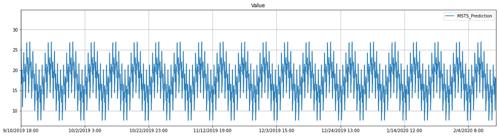

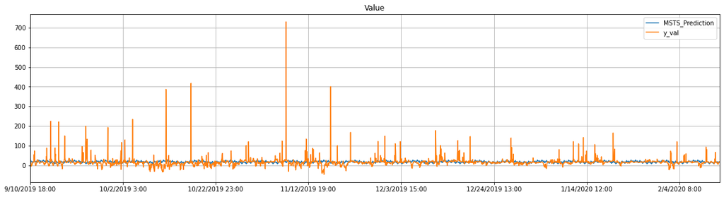

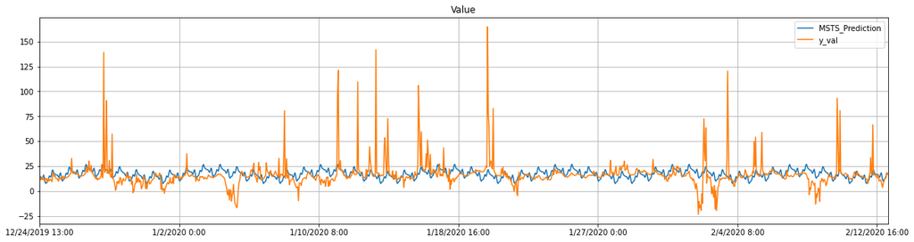

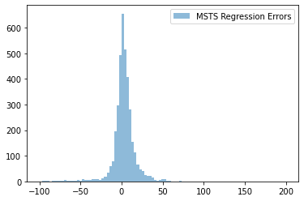

```
Validation Set RMSE for MSTS TimeSeries Benchmark: 25.238
Validation Set Mean error for MSTS TimeSeries Benchmark: 0.986
```

```python
## MSTS Model
## Forecast through validation period
n_val = len(y_val)
msts_preds_val = pd.DataFrame(data=msts_model.forecast(steps=n_val), index=index_val, columns=['MSTS_Prediction'])

## Plot all forecasted validation data
plot_df(msts_preds_val)

msts_preds_val['y_val'] = y_val

## Plot all validation data for forecasted vs. actual price, then zoom in one smaller period
plot_df(msts_preds_val)
plot_df(msts_preds_val[2500:])

## RMSE on MSTS model - Validation set
rmse_val_MSTS = np.sqrt(mean_squared_error(y_val, msts_preds_val['MSTS_Prediction'].values))
msts_preds_val['MSTS_error'] = msts_preds_val['MSTS_Prediction'] - msts_preds_val['y_val']

bins = np.linspace(-100, 200, 100)
pyplot.hist(msts_preds_val['MSTS_error'], bins, alpha=0.5, label='MSTS Regression Errors')
pyplot.legend(loc='upper right')
pyplot.show()

## Plot the histogram of validation set errors
print("Validation Set RMSE for MSTS TimeSeries Benchmark: %.3f" % rmse_val_MSTS)
print("Validation Set Mean error for MSTS TimeSeries Benchmark: %.3f" % np.mean(msts_preds_val['MSTS_error']))
```

## Extra Trees Regression Model

Next we develop an Extra Trees Regression model and use randomized grid search to hypertune the n_estimators and max_features parameters. 3 fold cross validation is performed with RMSE as the scoring metric.

```python
## Extra Trees Model
param_distribs = {
        'n_estimators': randint(low=1, high=200),
        'max_features': randint(low=1, high=16),
    }

extraforest = ExtraTreesRegressor(bootstrap=True,oob_score=True,n_jobs=-1, random_state=42)

## Randomized Search on ExtraTrees hyperparameters
rnd_search = RandomizedSearchCV(extraforest, param_distributions=param_distribs, n_iter=10, cv=3,
                          scoring='neg_root_mean_squared_error', random_state=42)

## Run randomized search
rnd_search.fit(X_train.values, y_train.values)
```

```
RandomizedSearchCV(cv=3, error_score=nan,
                   estimator=ExtraTreesRegressor(bootstrap=True, ccp_alpha=0.0,
                                                 criterion='mse',
                                                 max_depth=None,
                                                 max_features='auto',
                                                 max_leaf_nodes=None,
                                                 max_samples=None,
                                                 min_impurity_decrease=0.0,
                                                 min_impurity_split=None,
                                                 min_samples_leaf=1,
                                                 min_samples_split=2,
                                                 min_weight_fraction_leaf=0.0,
                                                 n_estimators=100, n_jobs=-1,
                                                 oob_score=True,
                                                 ran...
                   iid='deprecated', n_iter=10, n_jobs=None,
                   param_distributions={'max_features': <scipy.stats._distn_infrastructure.rv_frozen object at 0x0000000049AD60B8>,
                                        'n_estimators': <scipy.stats._distn_infrastructure.rv_frozen object at 0x0000000049AE55F8>},
                   pre_dispatch='2*n_jobs', random_state=42, refit=True,
                   return_train_score=False,
                   scoring='neg_root_mean_squared_error', verbose=0)
```

```python
# store best estimator
final_ET_model = rnd_search.best_estimator_

# Fit the best Extra Trees Model with Cross Validation
final_ET_model.fit(X_train.values, y_train.values)

cv_scores = cross_val_score(final_ET_model,
                            X_train.values, y_train, cv=10, scoring='neg_root_mean_squared_error')
```

The parameters of the tuned final Extra Trees model are:

```python
final_ET_model
```

```
ExtraTreesRegressor(bootstrap=True, ccp_alpha=0.0, criterion='mse',
                    max_depth=None, max_features=11, max_leaf_nodes=None,
                    max_samples=None, min_impurity_decrease=0.0,
                    min_impurity_split=None, min_samples_leaf=1,
                    min_samples_split=2, min_weight_fraction_leaf=0.0,
                    n_estimators=88, n_jobs=-1, oob_score=True, random_state=42,
                    verbose=0, warm_start=False)
```

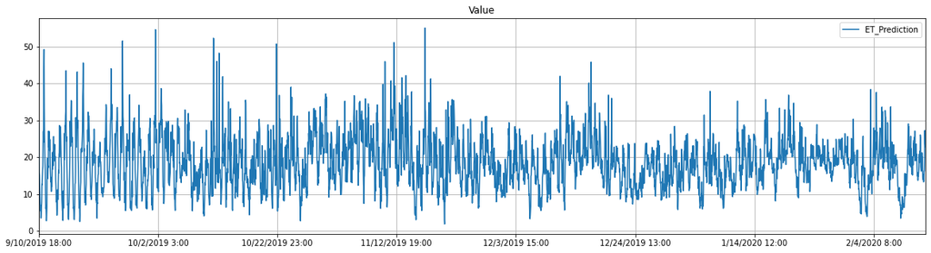

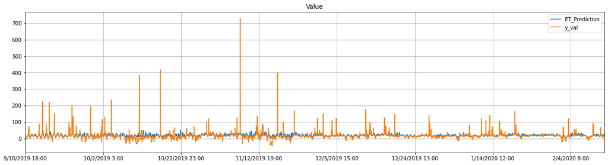

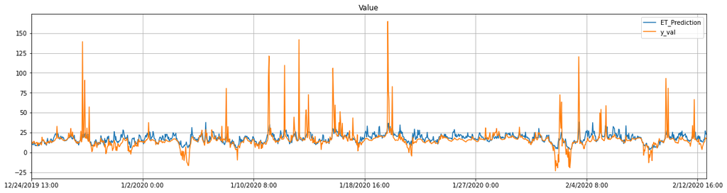

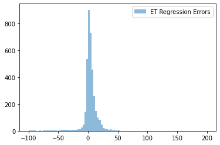

```
Extra Trees Model: 10-Fold CV average training rmse score: 23.4801, validation score: 23.0991
Validation Set Mean error for Extra Trees Model: 2.264
```

```python
## Extra Trees Model
## Forecast through validation period
ET_preds_val = pd.DataFrame(data=final_ET_model.predict(X_val.values), index=index_val, columns=['ET_Prediction'])

## Plot all forecasted validation data
plot_df(ET_preds_val)

ET_preds_val['y_val'] = y_val

## Plot all validation data for forecasted vs. actual price, then zoom in one smaller period
plot_df(ET_preds_val)
plot_df(ET_preds_val[2500:])

## RMSE on MSTS model - Validation set
rmse_val_ET = np.sqrt(mean_squared_error(y_val, ET_preds_val['ET_Prediction'].values))
ET_preds_val['ET_error'] = ET_preds_val['ET_Prediction'] - ET_preds_val['y_val']

bins = np.linspace(-100, 200, 100)
pyplot.hist(ET_preds_val['ET_error'], bins, alpha=0.5, label='ET Regression Errors')
pyplot.legend(loc='upper right')
pyplot.show()

## Plot the histogram of validation set errors
print("Extra Trees Model: 10-Fold CV average training rmse score: {:.4f}, validation score: {:.4f}"
      .format(-cv_scores.mean(), rmse_val_ET))
print("Validation Set Mean error for Extra Trees Model: %.3f" % np.mean(ET_preds_val['ET_error']))
```

The average validation RMSE for the Extra Trees model is not much better than the AR regression model. Whether or not it's significant will be tested later, but it does not appear so.

Re-Running ExtraTrees with PCA transformation

Re-evaluate Extra Trees model with PCA transformation on the features first.

```python
from sklearn.decomposition import PCA

pca = PCA(n_components=0.90)
X_train_pca = pca.fit_transform(X_train.values)
X_val_pca = pca.transform(X_val.values)
X_test_pca = pca.transform(X_test.values)

X_train_pca.shape, X_val_pca.shape
```

```
((18584, 133), (3717, 133))
```

```python
## Train the Extra Trees model with cross validation and hyertuning, using PCA
rnd_search.fit(X_train_pca, y_train.values)
final_ET_PCA_model = rnd_search.best_estimator_
```

```python
## Fit the final model and check validation RMSE
final_ET_PCA_model.fit(X_train_pca, y_train.values)

cv_scores = cross_val_score(final_ET_PCA_model,
                            X_train_pca, y_train, cv=10, scoring='neg_root_mean_squared_error')
```

```python
ypred = final_ET_PCA_model.predict(X_val_pca)
rmse_val_ET_PCA = np.sqrt(mean_squared_error(y_val, ypred))
errors_ET_PCA_val = ypred - y_val.values

print("Extra Trees w PCA: 10-Fold CV average score: {:.4f}, validation score: {:.4f}"
      .format(-cv_scores.mean(), rmse_val_ET_PCA))
```

```
Extra Trees w PCA: 10-Fold CV average score: 23.4801, validation score: 24.5733
```

The PCA transformation does not appear helpful for the Extra Trees model. It will not be used subsequently.

## Random Forest Model

```python
## Random Forest Model
param_distribs = {
        'n_estimators': randint(low=1, high=200),
    }

forest = RandomForestRegressor(n_jobs=-1, random_state=42)

## Randomized Search on ExtraTrees hyperparameters
rnd_search = RandomizedSearchCV(forest, param_distributions=param_distribs, n_iter=10, cv=3,
                          scoring='neg_root_mean_squared_error', random_state=42)

## Run randomized search
rnd_search.fit(X_train.values, y_train.values)

# store best estimator
final_RF_model = rnd_search.best_estimator_
```

```python
# Fit the best Extra Trees Model
final_RF_model.fit(X_train.values, y_train.values)

cv_scores_RF = cross_val_score(final_RF_model, X_train.values, y_train, cv=10, scoring='neg_root_mean_squared_error')
```

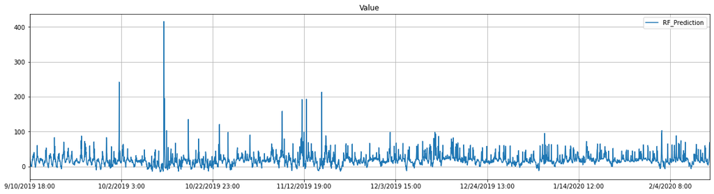

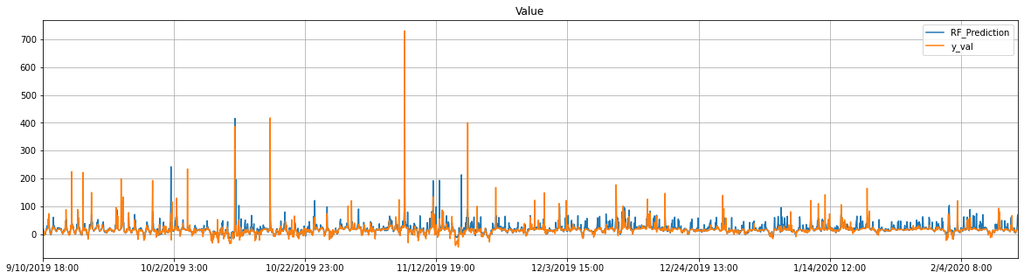

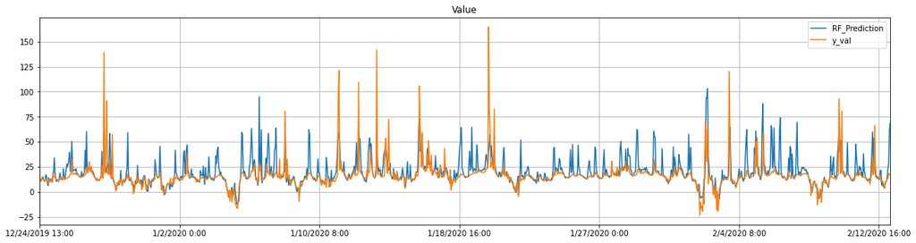

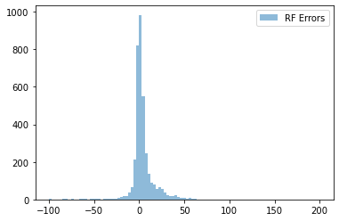

```
Random Forest Model: 10-Fold CV average training rmse score: 23.4801, validation score: 23.2529
Validation Set Mean error for Random Forest Model: 3.143
```

```python
## Random Forest Model
## Forecast through validation period
RF_preds_val = pd.DataFrame(data=final_RF_model.predict(X_val.values), index=index_val, columns=['RF_Prediction'])

## Plot all forecasted validation data
plot_df(RF_preds_val)

RF_preds_val['y_val'] = y_val

## Plot all validation data for forecasted vs. actual price, then zoom in one smaller period
plot_df(RF_preds_val)
plot_df(RF_preds_val[2500:])

## RMSE on MSTS model - Validation set
rmse_val_RF = np.sqrt(mean_squared_error(y_val, RF_preds_val['RF_Prediction'].values))
RF_preds_val['RF_error'] = RF_preds_val['RF_Prediction'] - RF_preds_val['y_val']

bins = np.linspace(-100, 200, 100)
pyplot.hist(RF_preds_val['RF_error'], bins, alpha=0.5, label='RF Errors')
pyplot.legend(loc='upper right')
pyplot.show()

## Plot the histogram of validation set errors
print("Random Forest Model: 10-Fold CV average training rmse score: {:.4f}, validation score: {:.4f}"
      .format(-cv_scores_RF.mean(), rmse_val_RF))
print("Validation Set Mean error for Random Forest Model: %.3f" % np.mean(RF_preds_val['RF_error']))
```

## ANN Model Prediction

```python
feature_num = X_train.shape[1]

def MSE(y_true,y_pred):
    mse = mean_squared_error(y_true, y_pred)
    return mse

# Function to create model, required for KerasRegressor
def new_model(batch_norm = False, dropout=False, dropout_rate=0.2,
              l = .0001, b1 = 0.9, b2 = 0.999,
              layers = 5, neurons = 50,
              activation = ["elu"],
              initializer = ["he_normal"],
              optimizer="Adam"):

    if activation == "selu":
        initializer = "lecun_normal"

    if activation == "relu":
        initializer = "he_normal"

    if activation == "elu":
        initializer = "he_normal"

    # build new model
    model = keras.models.Sequential()
    model.add(keras.layers.Flatten(input_shape=[feature_num]))

    if batch_norm == True:
        keras.layers.BatchNormalization()

    if dropout == True:
        model.add(keras.layers.Dropout(rate=dropout_rate))

    for layer in range(layers):
        model.add(keras.layers.Dense(neurons, activation = activation, kernel_initializer = initializer))

        if batch_norm == True:
            keras.layers.BatchNormalization()

        if dropout == True:
            model.add(keras.layers.Dropout(rate=dropout_rate))

    model.add(keras.layers.Dense(1))

    if optimizer == "Adam":
        optimizer = keras.optimizers.Adam(lr=l, beta_1=b1, beta_2=b2)

    if optimizer == "SGD":
        optimizer = keras.optimizers.SGD(lr=0.01, momentum=0.9, nesterov=True, decay=1e-4)

    # Compile model
    model.compile(loss="mse", optimizer=optimizer, metrics=[tf.keras.metrics.RootMeanSquaredError()])

    return model
```

```python
l = [ 0.001]
b1 = [0.9]
b2 = [0.999]
layers = [2, 3, 5, 7]
neurons = [5, 10, 30, 50]

batch_norm = [True]
dropout = [True, False]
optimizer = ["Nadam", "NAG"]
activation = ["selu", "elu", "relu"]

ANN = KerasRegressor(build_fn=new_model)
param_grid = dict(batch_norm = batch_norm, dropout = dropout,
                  l = l, b1 = b1, b2 = b2,
                  layers = layers, neurons = neurons,
                  activation = activation,
                  optimizer = optimizer)
```

```python
## Grid Search on ANN hyperparameters
grid = GridSearchCV(estimator=ANN, param_grid=param_grid, cv=3, scoring='neg_root_mean_squared_error')
```

```python
# Save best model fit only
checkpoint_cb = keras.callbacks.ModelCheckpoint("best_ANN_06-08.h5",
                                                save_best_only=True)
# Stop early
early_stopping_cb = keras.callbacks.EarlyStopping(patience=10,
                                                  min_delta=0.001,
                                                  restore_best_weights=True)

# Performance scheduling learning rate
lr_scheduler = keras.callbacks.ReduceLROnPlateau(factor=0.5, patience=5)

## hypertune parameters with grid search
import time
start = time.time()

grid_result = grid.fit(X_train.values, y_train.values, epochs=10,
                       validation_data=(X_val.values, y_val.values),
                       callbacks=[checkpoint_cb, early_stopping_cb, lr_scheduler])
end = time.time()
```

[output not shown]

[output cut: 234 more lines]

[output not shown]

```python
ANN_best = grid_result.best_estimator_
```

```python
ANN_result = ANN_best.fit(X_train.values, y_train.values, epochs=400,
                       validation_data=(X_val.values, y_val.values),
                       callbacks=[checkpoint_cb, early_stopping_cb, lr_scheduler])
```

```
Train on 18584 samples, validate on 3717 samples
```

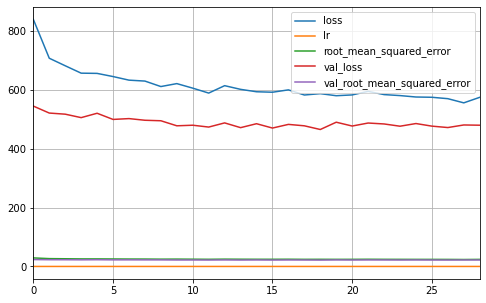

```python
## Graph learning curve of ANN over epochs, over-fitting does not appear present
pd.DataFrame(ANN_result.history).plot(figsize=(8,5))
plt.grid(True)
plt.gca().set_ylim=(0,1)
plt.show()
```

```python
# Forecast 365 days ahead
ANN_y_pred_val = ANN_best.predict(X_val.values)
```

```python
mse = mean_squared_error(ANN_y_pred_val, y_val)
rmse_val_ANN = np.sqrt(mse)
print('The Root Mean Squared Error from the ANN forecast: ', rmse_val_ANN)
```

```
The Root Mean Squared Error from the ANN forecast:  21.559220883927406
```

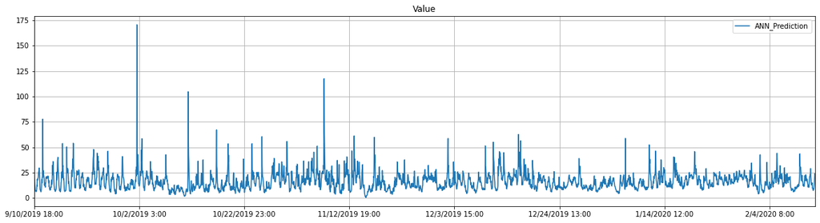

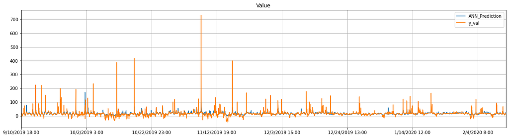

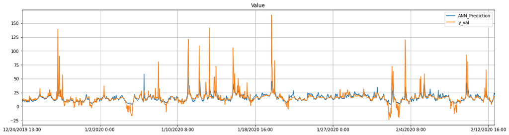

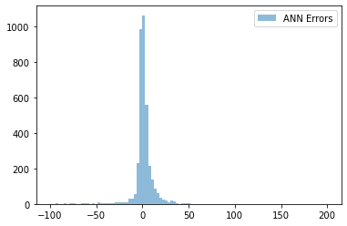

```
ANN Model validation RMSE score: 21.5592
Validation Set Mean error for ANN Model: 0.109
```

```python
## ANN Model
## Forecast through validation period
ANN_preds_val = pd.DataFrame(data=ANN_best.predict(X_val.values), index=index_val, columns=['ANN_Prediction'])

## Plot all forecasted validation data
plot_df(ANN_preds_val)

ANN_preds_val['y_val'] = y_val

## Plot all validation data for forecasted vs. actual price, then zoom in one smaller period
plot_df(ANN_preds_val)
plot_df(ANN_preds_val[2500:])

## RMSE on MSTS model - Validation set
rmse_val_ANN = np.sqrt(mean_squared_error(y_val, ANN_preds_val['ANN_Prediction'].values))
ANN_preds_val['ANN_error'] = ANN_preds_val['ANN_Prediction'] - ANN_preds_val['y_val']

bins = np.linspace(-100, 200, 100)
pyplot.hist(ANN_preds_val['ANN_error'], bins, alpha=0.5, label='ANN Errors')
pyplot.legend(loc='upper right')
pyplot.show()

## Plot the histogram of validation set errors
print("ANN Model validation RMSE score: {:.4f}"
      .format(rmse_val_ANN))
print("Validation Set Mean error for ANN Model: %.3f" % np.mean(ANN_preds_val['ANN_error']))
```

## All Models Comparison on Test Data Set

```python
## Benchmark Categorical Regression Forecast Y Test predictions and errors

# Predict over test set
CatReg_test_preds = pd.DataFrame(data=model_CatReg.predict(X_test_cat_1hot.values), index=index_test, columns=['CatReg_Pred'])
CatReg_test_preds['y_test'] = y_test

rmse_test_CatReg = np.sqrt(mean_squared_error(CatReg_test_preds['CatReg_Pred'].values, y_test))
# CatReg_test_preds["Errors"] = pd.DataFrame(CatReg_test_preds['CatReg_Pred'] - y_test.values, index=index_test, columns=["Errors"])

CatReg_test_preds['error'] = pd.DataFrame(CatReg_test_preds['CatReg_Pred'] - CatReg_test_preds['y_test'])
mean_err_CatReg_test = np.mean(CatReg_test_preds['error'])

print('Categorical Regression Model RMSE on Test Set:', rmse_test_CatReg)
print('Categorical Regression Model Mean Error on Test Set:', mean_err_CatReg_test)
```

```
Categorical Regression Model RMSE on Test Set: 20.581693041784245
Categorical Regression Model Mean Error on Test Set: 4.591818795633451
```

```python
## Benchmark AR Regression Forecast Y Test predictions and errors

# Predict over test set
LM_test_preds = model.predict(X_test_lm.values)

rmse_test_lm = np.sqrt(mean_squared_error(LM_test_preds, y_test))
errors_ARLM_test = pd.DataFrame(LM_test_preds - y_test.values, index=index_test, columns=["error"])
#errors_ARLM_test = LM_test_preds.values - y_test.values

mean_err_ARLM_test = np.mean(errors_ARLM_test["error"].values)
print('Linear Model with AR RMSE on test set: ',  rmse_test_lm)
print('Linear Model with AR Mean Errors on test set:', mean_err_ARLM_test)
```

```
Linear Model with AR RMSE on test set:  18.458559554500546
Linear Model with AR Mean Errors on test set: -0.1249637554343496
```

```python
## Benchmark MSTS Forecast Y Test predictions and errors
# Predict over test set

n_test = len(y_val)+len(y_test)
msts_preds_val_test = pd.DataFrame(data=msts_model.forecast(steps=n_test), columns=['MSTS_Prediction'])

msts_preds_test = msts_preds_val_test[len(y_val):]
msts_preds_test.index = index_test
msts_preds_test['y_test'] = y_test

rmse_test_MSTS = np.sqrt(mean_squared_error(msts_preds_test['MSTS_Prediction'].values, y_test))
msts_preds_test['MSTS_error'] = pd.DataFrame(msts_preds_test['MSTS_Prediction'] - msts_preds_test['y_test'])

mean_err_MSTS_test = np.mean(msts_preds_test['MSTS_error'])

from scipy.stats import ttest_rel
MSTS_pval = ttest_rel(msts_preds_test['MSTS_error'].values, errors_ARLM_test["error"].values)[1]

print('MSTS Model RMSE on Test Set:', rmse_test_MSTS)
print('MSTS Model Mean Error on Test Set:', mean_err_MSTS_test)
print('MSTS vs ARLM t-test pval: ', MSTS_pval)
```

```
MSTS Model RMSE on Test Set: 21.312484708476152
MSTS Model Mean Error on Test Set: 4.699984686641617
MSTS vs ARLM t-test pval:  1.140559099982659e-134
```

```python
## Student's t test for statistically significant errors across models
## Extra trees model without PCA

ypred_ET_test = pd.DataFrame(final_ET_model.predict(X_test.values), columns=['ET_Prediction'])
ypred_ET_test['y_test'] = y_test.values

## Compute test errors
ypred_ET_test['error'] = pd.DataFrame(ypred_ET_test['ET_Prediction'] - ypred_ET_test['y_test'])

## RMSE for Test set on RF model
rmse_test_ET = np.sqrt(mean_squared_error(ypred_ET_test['y_test'].values, ypred_ET_test['ET_Prediction'].values))
mean_err_ET_test = np.mean(ypred_ET_test['error'] )

## T test statistics
ET_LM_pval = ttest_rel(ypred_ET_test['error'].values, errors_ARLM_test["error"].values)[1]

print('Extra Trees Mean Error Test', mean_err_ET_test)
print('Extra Trees Model RMSE on test set: ',  rmse_test_ET)
print('Extra Trees vs ARLM model t-test pval: ', ET_LM_pval)
```

```
Extra Trees Mean Error Test 3.3262976657980703
Extra Trees Model RMSE on test set:  18.576897507754197
Extra Trees vs ARLM model t-test pval:  2.8187291054281115e-116
```

The best ExtraForest model is statistically significant in having a larger (worse) avg error than the AR regression model.

```python
## Random Forest Model Prediction on test set
ypred_RF_test = pd.DataFrame(final_RF_model.predict(X_test.values))

## Compute test errors
errors_RF_test = ypred_RF_test.values - y_test.values
LM_RF_ttest = ttest_rel(errors_RF_test, errors_ARLM_test)

## RMSE for Test set on RF model
rmse_test_RF = np.sqrt(mean_squared_error(y_test.values, ypred_RF_test.values))
mean_err_RF_test = np.mean(errors_RF_test)

RF_LM_pval = ttest_rel(errors_RF_test, errors_ARLM_test)[1]

print('Random Forest Mean Error Test', mean_err_RF_test)
print('Random Forest Model RMSE on test set: ',  rmse_test_RF)
print('Random Forest vs ARLM model t-test pval: ', RF_LM_pval)
```

```
Random Forest Mean Error Test 5.195323473308936
Random Forest Model RMSE on test set:  20.252978780944492
Random Forest vs ARLM model t-test pval:  [3.71813481e-56]
```

The best Random Forest model is also statistically significant in having a larger (worse) avg error than the AR regression model.

```python
## ANN Model
## RMSE on Test Set and Student's t test for statistically significant errors across models

ANN_y_pred_test = pd.DataFrame(ANN_best.predict(X_test.values))

## Compute test errors
errors_ANN_test = ANN_y_pred_test.values - y_test.values

from scipy.stats import ttest_rel
LM_ANN_ttest = ttest_rel(errors_ANN_test, errors_ARLM_test)

## RMSE for Test set on RF model
rmse_test_ANN = np.sqrt(mean_squared_error(ANN_y_pred_test, y_test))
mean_err_ANN_test = np.mean(errors_ANN_test)
ANN_LM_pval = ttest_rel(errors_ANN_test, errors_ARLM_test)[1]

print('ANN Mean Error Test ', mean_err_ANN_test)
print('ANN Model RMSE on test set: ',  rmse_test_ANN)
print('ANN vs ARLM model t-test pval: ', ANN_LM_pval)
```

```
ANN Mean Error Test  1.4443375629564423
ANN Model RMSE on test set:  17.51336088873218
ANN vs ARLM model t-test pval:  [1.74550245e-47]
```

The following charts graph the forecasting errors of the ANN model vs. AR Regression, Random Forest and Extra Trees specifically, which are the underlying data for the t-tests.

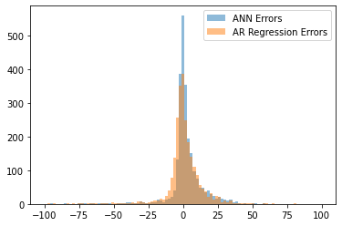

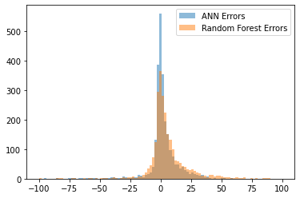

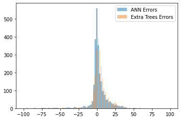

```python
## ANN Test errors vs AR Regression test
bins = np.linspace(-100, 100, 100)
pyplot.hist(errors_ANN_test, bins, alpha=0.5, label='ANN Errors')
pyplot.hist(errors_ARLM_test.values, bins, alpha=0.5, label='AR Regression Errors')
pyplot.legend(loc='upper right')
pyplot.show()

## ANN errors vs. Random Forest test errors
bins = np.linspace(-100, 100, 100)
pyplot.hist(errors_ANN_test, bins, alpha=0.5, label='ANN Errors')
pyplot.hist(errors_RF_test, bins, alpha=0.5, label='Random Forest Errors')
pyplot.legend(loc='upper right')
pyplot.show()

## ANN errors vs ExtraTrees test errors
bins = np.linspace(-100, 100, 100)
pyplot.hist(errors_ANN_test, bins, alpha=0.5, label='ANN Errors')
pyplot.hist(errors_ET_test, bins, alpha=0.5, label='Extra Trees Errors')
pyplot.legend(loc='upper right')
pyplot.show()
```

Lastly, we summarize all the key statistics in the following table and draw our conclusions.

```python
## Summarize RMSE statistics
summary = pd.DataFrame([[rmse_val_lm, rmse_test_lm, mean_err_ARLM_test],
                        [rmse_val_CatReg, rmse_test_CatReg, mean_err_CatReg_test],
                        [rmse_val_MSTS, rmse_test_MSTS, mean_err_MSTS_test],
                        [rmse_val_ET, rmse_test_ET, mean_err_ET_test],
                        [rmse_val_RF, rmse_test_RF, mean_err_RF_test],
                        [rmse_val_ANN, rmse_test_ANN, mean_err_ANN_test]]).T
summary = summary.round(1)
```

```python
summary.columns = ["LM Regression", "Categorical Reg.", "MSTS", "Extra Trees", "Random Forest", "ANN"]
summary.index = ["RMSE Validation Set:", "RMSE Test Set:", "Mean Error Test Set:"]
summary
```

|  | LM Regression | Categorical Reg. | MSTS | Extra Trees | Random Forest | ANN |
| --- | --- | --- | --- | --- | --- | --- |
| RMSE Validation Set: | 23.1 | 24.7 | 25.2 | 23.1 | 23.3 | 21.6 |
| RMSE Test Set: | 18.5 | 20.6 | 21.3 | 18.6 | 20.3 | 17.5 |
| Mean Error Test Set: | -0.1 | 4.6 | 4.7 | 3.3 | 5.2 | 1.4 |

```python
## ANN Errors t-tests vs other models
errors_ANN_test = pd.DataFrame(errors_ANN_test, index=index_test, columns=["ANN_error"])
errors_RF_test = pd.DataFrame(errors_RF_test, index=index_test, columns=["RF_error"])

ANN_CatReg_pval = ttest_rel(errors_ANN_test["ANN_error"].values, CatReg_test_preds['error'].values)[1]
print('ANN errors vs CatReg pval: ', ANN_CatReg_pval)

ANN_MSTS_pval = ttest_rel(errors_ANN_test["ANN_error"].values, msts_preds_test['MSTS_error'].values)[1]
print('ANN errors vs MSTS pval: ', ANN_MSTS_pval)

ANN_ET_pval = ttest_rel(errors_ANN_test["ANN_error"], ypred_ET_test['error'].values)[1]
print('ANN errors vs Extra Trees pval: ', ANN_ET_pval)

ANN_RF_pval = ttest_rel(errors_ANN_test["ANN_error"], errors_RF_test["RF_error"].values)[1]
print('ANN errors vs Random Forest pval: ', ANN_RF_pval)
```

```
ANN errors vs CatReg pval:  1.1429054928273482e-118
ANN errors vs MSTS pval:  1.0282652387299566e-87
ANN errors vs Extra Trees pval:  4.805521090122109e-77
ANN errors vs Random Forest pval:  2.9191214866991057e-34
```

CONCLUSION:

Of all models, the ANN model has the best RMSE score in both the validation and test data sets.

The ANN model does have statistical significance in better mean forecasting error than the MSTS time series model, Categorical Regression, as well as the Random Forest and Extra Trees models. It's noteworthy that the AR linear regression model did have a lower mean error on the test set than the ANN model, and seems to better remove the average bias, however it does not have a lower RMSE than the ANN.

This provides evidence that the ANN model appears to be a better performing forecasting model for this problem statement than decision tree regressors and timeseries/regression models.

A final note...It's noteworthy that the test set RMSEs are all lower than the validation set RMSEs for each model. One reason may be that there are fewer instances of high prices in the testing set than the training or validation sets. Stratified sampling could have improved this however I wanted to preserve the timeseries nature of the dataset. Also, it was difficult to use the timeseriessplit function for cross validation as some of the models are not treated as a timeseries but rather independent features (Extra Trees, Random Forest and ANN).

```
array([[<matplotlib.axes._subplots.AxesSubplot object at 0x00000000BC1021D0>]],
      dtype=object)
```

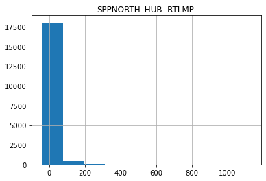

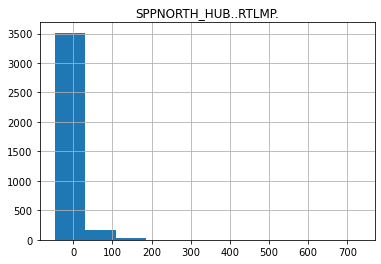

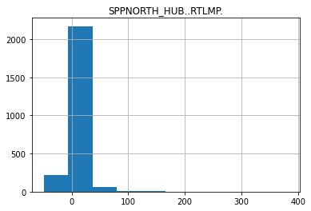

```python
y_train.hist()
y_val.hist()
y_test.hist()
```